# Debugging & Tidyeval

Jake Riley - 6/9/2022

See [here](https://rjake.github.io/analytics-deep-dive/sessions/r-functions/slides.html#1) for slides and [here](https://www.github.com/rjake/analytics-deep-dive/blob/main/sessions/r-functions/index.Rmd) for the raw code

```r
library(tidyverse)
library(glue)
library(lubridate)
library(gt)
library(rlang)
```

## Writing functions

### A simple function

This will return a phrase such as “1 - 10” or “18 to 21”

```r
format_range <- function(x, sep = " - ") {
  range(x, na.rm = TRUE) |>
    paste(collapse = sep)
}
```

I could also have also used this logic:

```r
paste(
  min(x, na.rm = TRUE), sep, max(x, na.rm = TRUE)
)
```

Let’s look at some outputs

| test | output |
| --- | --- |
| format_range(1:10) | 1 - 10 |
| format_range(10:1) | 1 - 10 |
| format_range(1:10, sep = " up to ") | 1 up to 10 |
| format_range(1) | 1 - 1 |
| format_range(-1:1, sep = " ... ") | -1 ... 1 |
| format_range(Sys.Date() + 0:10) | 2022-06-08 - 2022-06-18 |
| format_range(letters) | a - z |

**It’s not perfect**

- “1 - 1” should just return “1”
- Dates could be formatted better

**It also throws an error on factors**

- The user doesn’t know where `'range'` is coming from

  ```r
  format_range(as.factor(letters))
  ```

  ```
  Error in Summary.factor(structure(1:26, levels = c("a", "b", "c", "d", : 'range' not meaningful for factors
  ```

### Alerts & errors

- There are 3 levels of alerts

  ```r
  message("I'll let you know but won't stop you")

  warning("ok... but are you sure?")

  stop("sorry pal, not going to happen :(", call. = FALSE)
  ```

  ```
  Error: sorry pal, not going to happen :(
  ```

- Use messages when possible
- Try to help the user figure out what went wrong

### Revised function

Let’s update our function to be more informative

```r
format_range <- function(x, sep = " - ") {
  # add infomative error message
  if (is.factor(x)) {
    stop("Works with numbers and dates but not factors")
  }

  # warn about character values c(1, 3, 20) will return 3 as max not 20
  if (is.character(x)) {
    message("meant for numeric inputs, results may be unexpected")
  }

  # early return if a single value
  if (length(unique(x)) == 1) {
    return(paste(x, "only"))
  }

  res <- range(x, na.rm = TRUE)

  if (is.Date(res) | is.POSIXct(res)) {
    res <- format(res, "%B%e, %Y") # June 1, 2022
  }

  paste(res, collapse = sep)
}
```

| test | orig | new |
| --- | --- | --- |
| format_range(1:10) | 1 - 10 | 1 - 10 |
| format_range(10:1) | 1 - 10 | 1 - 10 |
| format_range(1:10, sep = " up to ") | 1 up to 10 | 1 up to 10 |
| format_range(1) | 1 - 1 | 1 only |
| format_range(-1:1, sep = " ... ") | -1 ... 1 | -1 ... 1 |
| format_range(Sys.Date() + 0:10) | 2022-06-08 - 2022-06-18 | June 8, 2022 - June18, 2022 |
| format_range(letters) | a - z | a - z |

### Document with `roxygen` syntax

Put cursor on function then use `Code > Insert Roxygen Skeleton`

- Uses `#'` and `#' @` as documentation
- Used heavily in package development
- At a minimum, include a title (top line) and `@examples`

```r
#' Returns the min & max values as a concatenated value
#' @param x a vector that is not a factor
#' @param sep the text to put between min(x) and max(x)
#'
#' @examples
#' format_range(x = 1:10)
#' format_range(x = 1:10, sep = " through ")
#' format_range(x = economics$date, sep = " to ")
format_range <- function(x, sep = " - ") {
  range(x, na.rm = TRUE) |>
    paste(collapse = sep)
}
```

## Debugging

### Functions you wrote

Sometimes I’ll add helper vars in the comments, especially for tidy evaluation (up next)

```r
format_range <- function(x, sep = " - ") {
  # x <- 1:10; sep <- "-"
  ...
}
```

**`debugonce()`** will turn on an interactive debugger. This can really help!

```r
debugonce(format_range)

format_range(x = as.factor(c(1,3,20)))
# try changing x to a character once the debugger is open
```

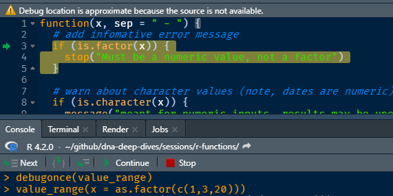

debugger browser

Note the buttons for Next, Into, Execute Remaining, Continue, and Stop

You can also add `browser()` inside your function to look around

```r
with_browser <- function(x, sep = " - ") {
  res <- range(x, na.rm = TRUE)

  browser()                  # <------- here
  paste(res, sep = sep)
}

with_browser(x = 1:10)
# I need 'collapse', not 'sep'
```

### Functions other people wrote

You can also see how functions are created by calling them without `()`

```r
forcats::fct_rev
```

```
function (f)
{
    f <- check_factor(f)
    lvls_reorder(f, rev(lvls_seq(f)))
}
<bytecode: 0x000001bfce9363a0>
<environment: namespace:forcats>
```

Note, sometimes you’ll see `UseMethod()`. You can access the code using `pkg:::fn` but methods are a special way to write functions and out of scope for today.

```r
dplyr::filter
```

```
function (.data, ..., .preserve = FALSE)
{
    UseMethod("filter")
}
<bytecode: 0x000001bfcadf5308>
<environment: namespace:dplyr>
```

```r
dplyr:::filter.data.frame
```

```
function (.data, ..., .preserve = FALSE)
{
    loc <- filter_rows(.data, ..., caller_env = caller_env())
    dplyr_row_slice(.data, loc, preserve = .preserve)
}
<bytecode: 0x000001bfd2f76cc8>
<environment: namespace:dplyr>
```

### F2

F2 will let you “browse” any function. Note: you must have the package loaded or the function in your environment

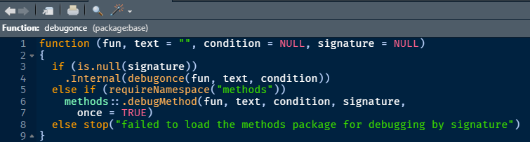

F2 function browser

## Tidyeval

lookup table

**What’s nice about functions in the `tidyverse` is that**

- you can pass column names without brackets or dollar signs
- they are also less verbose
- generally more consistent method

```r
# base R
mtcars$mpg[mtcars$mpg > 30 & mtcars$hp > 60]
#     ----

mtcars[mtcars$mpg > 30 & mtcars$hp > 60, "mpg"]
#                                      -------
subset(mtcars, mpg > 30 & hp > 60)$mpg
#                                 ----
```

```r
# tidyverse
mtcars |>
  filter(between(mpg, 30, 60)) |>
  pull(mpg)
```

**Unfortunately**

- they’re more complicated under the hood as the data frame is its own environment
- very hard (frustrating) to debug

### New Operators

#### `{{x}}` curly-curly

**In general**

- you’ll need to use **`{{x}}`**, called “curly-curly” or “embrace”
- you can often mock it up with `as.symbol("string")` or `quo(expr)`

```r
col_mean <- function(df, col) {
  # df <- mpg; col <- as.symbol("cty")
  df |>
    summarise(
      mean = mean({{col}}, na.rm = TRUE)
    )
}

airquality |>
  group_by(Month) |>
  col_mean(Wind)
```

| Month | mean |
| --- | --- |
| 5 | 11.62 |
| 6 | 10.27 |
| 7 | 8.942 |
| 8 | 8.794 |
| 9 | 10.18 |

```r
airquality |>
  group_by(Month) |>
  col_mean(Ozone)
```

| Month | mean |
| --- | --- |
| 5 | 23.62 |
| 6 | 29.44 |
| 7 | 59.12 |
| 8 | 59.96 |
| 9 | 31.45 |

#### `:=` the walrus

- You can dynamically affect the column names (left hand side) with the walrus operator `:=`
- You can add text by putting the embrace in quotes `"{{x}}_more_stuff"`

```r
col_difference <- function(df, x, y) {
  # df <- mpg; x = as.symbol("cty"); y = as.symbol("hwy")
  df |>
    summarise(
      {{x}} := mean({{x}}),
      {{y}} := mean({{y}})
    ) |>
    mutate(
      "avg_{{x}}_to_{{y}}" := {{x}} - {{y}}
    )
}
```

Let’s try it out

```r
mpg |>
  group_by(class) |>
  col_difference(
    x = hwy,
    y = cty
  )
```

| class | hwy | cty | avg_hwy_to_cty |
| --- | --- | --- | --- |
| 2seater | 24.8 | 15.4 | 9.4 |
| compact | 28.3 | 20.13 | 8.17 |
| midsize | 27.29 | 18.76 | 8.537 |
| minivan | 22.36 | 15.82 | 6.545 |
| pickup | 16.88 | 13 | 3.879 |
| subcompact | 28.14 | 20.37 | 7.771 |
| suv | 18.13 | 13.5 | 4.629 |

### Examples

#### Making a plot

You can use `{{x}}` in ggplot itself

```r
make_plot <- function(df, date, n, ...) {

  #               --------  -----
  ggplot(df, aes( {{date}}, {{n}} )) +
    geom_point(...) +
    theme_minimal()
}
```

Let’s see

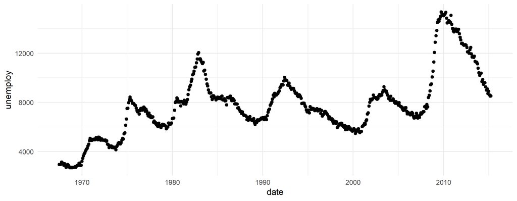

```r
make_plot(
  economics,
  date = date,
  n = unemploy
)
```

Because the output of `make_plot()` is a ggplot object, I can pipe on more steps with `+`

I can also adjust the look by filling in the `...`

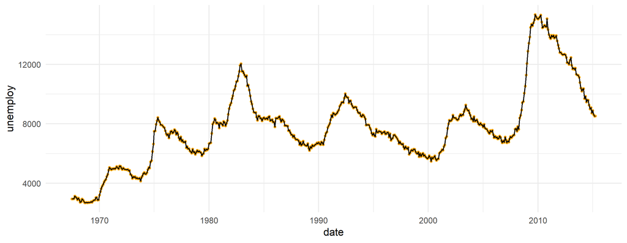

```r
make_plot(
  economics,
  date = date,
  n = unemploy,
  # passed via ...
  size = 1,
  color = "orange"
) +
  geom_line()
```

#### “Hard-coding”

Sometimes I hard code the variables I need so I don’t need `{{x}}` each time

- use `mutate()` or `transmute()` to give the columns static names
- use `rlang` functions `as_string(ensym(...))` outside of data frames to return a string

```r
make_plot_and_title <- function(df, date, n, ...) {
  plot_title <- paste( as_string(ensym(n)), "by", as_string(ensym(date)))

  df |>
    mutate(
      x = {{date}},       # <-----
      y = {{n}}           # <-----
    ) |>
    ggplot(aes(x, y)) +
    geom_line(color = "grey90", size = 2) +
    geom_point(...) +
    theme_minimal() +
    labs(
      title = str_to_title(plot_title),
      x = NULL,
      y = NULL
    )
}
```

Let’s try it out

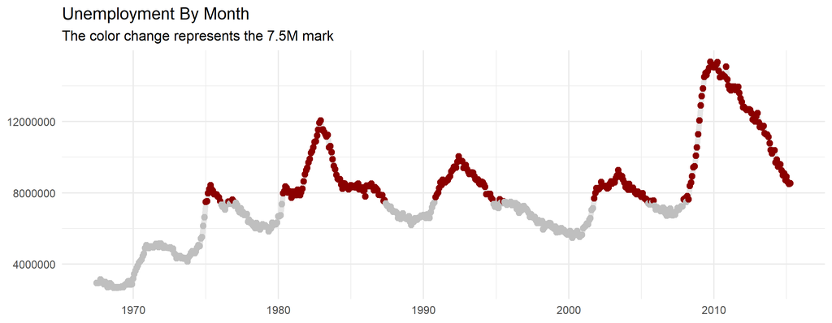

```r
economics |>
  # rename columns
  transmute(
    unemployment = unemploy * 1e3,
    month = date
  ) |>
  # new function
  make_plot_and_title(
    date = month,
    n = unemployment,
    # passed to ...
    mapping = aes(color = unemployment > 7.5e6),
    size = 2
  ) +
  scale_color_manual(values = c("grey75", "darkred")) +
  theme(legend.position = "none") +
  labs(subtitle = "The color change represents the 7.5M mark")
```

### Getting more complicated

When things get more complicated, I almost always leave in helpers

```r
#' Rollup data using summarise(across(...))
#'
#' @param name prefix for
#' @param cond the x or y condition used in compare_conditions()
#' @examples
#' aggregate_group(df = mtcars, cond = mpg > 30, cols = mpg, fns = lst(mean, sd))
aggregate_group <- function(df,
                            cond,
                            cols = where(is.numeric),
                            fns = lst(mean)) {
  # df <- mtcars; cond <- dplyr::quo(cyl > 4);
  # cols <- dplyr::quo(mpg); fns <- dplyr::lst(mean);

  df |>
    filter({{cond}}) |>
    summarise(
      across({{cols}}, fns, .names = "{.fn}_{.col}")
    )
}
```

Let’s try it out

```r
mtcars |>
  aggregate_group(cond = mpg > 30)
```

Table continues below

| mean_mpg | mean_cyl | mean_disp | mean_hp | mean_drat | mean_wt | mean_qsec |
| --- | --- | --- | --- | --- | --- | --- |
| 31.77 | 4 | 80.15 | 74 | 4.25 | 1.791 | 18.7 |

| mean_vs | mean_am | mean_gear | mean_carb |
| --- | --- | --- | --- |
| 1 | 1 | 4.25 | 1.5 |

This function seems pretty robust

```r
mpg |>
  group_by(class) |>
  aggregate_group(
    cond = (cyl == 4 & year == 2008),
    cols = c(drv, model),
    fns = list(
      dist = n_distinct,
      min = min,
      max = max,
      dig = ~sum(str_count(.x, "\\d"))
    )
  )
```

Table continues below

| class | dist_drv | min_drv | max_drv | dig_drv | dist_model |
| --- | --- | --- | --- | --- | --- |
| compact | 2 | 4 | f | 6 | 7 |
| midsize | 1 | f | f | 0 | 5 |
| pickup | 1 | 4 | 4 | 1 | 1 |
| subcompact | 1 | f | f | 0 | 2 |
| suv | 1 | 4 | 4 | 4 | 1 |

| min_model | max_model | dig_model |
| --- | --- | --- |
| a4 | jetta | 4 |
| altima | sonata | 0 |
| toyota tacoma 4wd | toyota tacoma 4wd | 1 |
| civic | tiburon | 0 |
| forester awd | forester awd | 0 |

### Mock inputs (lookup table)

- `quo()` will pass an expression like `cty > 18` or a symbol (name of an object) like `cty`, these aren’t evaluated until they are called in the data frame
- `as.symbol()` only takes a single variable `as.symbol("cty")`

| value of x | x is | need | in | how to use | mock-up for debugging |
| --- | --- | --- | --- | --- | --- |
| cty | symbol | column | df | select({{**x**}}) mutate(test = {{**x**}}) | x <- quo(cty) x <- as.symbol("cty") |
| cty | symbol | string | env | mutate(test = as_string(ensym(**x**))) p + labs(title = as_string(ensym(**x**))) | x <- as.symbol("cty") |
| "cty" | string | column | df | select(**x**) mutate(test = get(**x**) > 18) | x <- "cty" |
| cty > 18 | expression | condition | df | filter({{**x**}}) mutate(test = {{**x**}}) | x <- quo(cty > 18) |

An example trying them all out

```r
library(rlang)
rlang_test <- function(df, symbol, string) {
  list(
    column_from_symbol =
      mutate(df, "{{symbol}}_kph" := {{symbol}} * 1.6) |>
      slice(1),

    column_from_string =
      mutate(df, use_col = get(string)) |>
      slice(1),

    symbol_to_string_df =
      tibble(use_value = as_string(ensym(symbol))),

    symbol_to_string_env =
      paste("var =", as_string(ensym(symbol)))
  )
}
```

Let’s see if we get:

- **Wind_kph** = **11.84**
- use_col = **7.4**
- use_value = **Wind**
- var = **Wind**

```r
# debugonce(rlang_test)
rlang_test(
  df = airquality,
  symbol = Wind,
  string = "Wind"
)
```

```
$column_from_symbol
  Ozone Solar.R Wind Temp Month Day Wind_kph
1    41     190  7.4   67     5   1    11.84

$column_from_string
  Ozone Solar.R Wind Temp Month Day use_col
1    41     190  7.4   67     5   1     7.4

$symbol_to_string_df
# A tibble: 1 × 1
  use_value
  <chr>
1 Wind

$symbol_to_string_env
[1] "var = Wind"
```

## Environments

Be mindful of where you ask a function to look for object names

R will look for variables in this order

| order | location | example |
| --- | --- | --- |
| 1st | **data** | `mtcars$mpg` |
| 2nd | **function environment** | `mpg <- 2` |
| 3rd | **function arguments** | `mpg <- 3` |
| 4th | **global environment** | `mpg <- 4` |

```r
mpg <- 4                           # 4

add_kph <- function(df, mpg = 3) { # 3
  mpg <- 2                         # 2

  df |>                            # 1
    mutate(kph = mpg * 1.6) |>
    as_tibble()
}
```

```r
# would use mtcars$mpg
add_kph(mtcars)

# if not in data would use env 'mpg <- 2'
add_kph(airquality)

# if comment out 'mpg <- 2' will use default argument 'mpg = 3'
add_kph(airquality)

# if argument is supplied, will use 'mpg = 20'
add_kph(airquality, mpg = 20)

# if all the above is removed, it will look in the global env 'mpg <- 4'
add_kph(airquality)
```